# optimize_trials2

Contents

- More optimization trials¶
  - Trial 2.1¶
  - State points
  - Performance variables
  - Trial 2.2¶
    - Aside¶
  - Trial 2.3¶
  - Trial 2.4¶
  - Trial 2.5¶
- Scratch work¶

# More optimization trials

Previously, I tried throwing a bunch of optimizers at my model. I liked the results from the scipy.optimize routines COBYLA and BFGS. Let's try adjusting how we handle the constraints, and see if we get better results.

```python
%load_ext autoreload
%autoreload 2
```

```python
import matplotlib
import numpy
from IPython.display import HTML, SVG
```

```python
#matplotlib.use('svg')
import matplotlib.pyplot as plt
plt.rcParams['svg.fonttype'] = 'none'
plt.rcParams['font.sans-serif'] = 'Arial'
```

```python
from io import BytesIO
def pltsvg():
    imgdata = BytesIO()
    plt.savefig(imgdata)
    imgdata.seek(0)
    display(SVG(data=imgdata.read()))
```

```python
import ammonia1
import system_aqua1
import scipy.optimize
```

```python
T_heat_reject = 305.
UAgoal = 100
xB = [400, 1, T_heat_reject, 3, T_heat_reject, 5, 285, 4, T_heat_reject, 0.15]
bdry = system_aqua1.makeBoundary(xB)
```

### Trial 2.1

In general, here is how we compute the modified objective function. GenOpt manual suggests adding functions to the objective, namely separate barrier (B) and penalty (P) functions. The objective function is, with step number as $k$,

$$ Objective = -Q_{cooling}(x) + \mu_1 B(x) + \mu_2 P(x) $$$$ \mu_1 = k^{-2}$$$$ B(x) = \left(\sum_{j=1}^{N_B} g_j(x) \right) ^ {-1} $$$$\mu_2 = k^{2}$$$$ P(x) = \sum_{j=N_B+1}^{N_B + N_P} g_j(x)$$

GenOpt implements a mechanism to pass in the step number. However, using the scipy.optimize routines, passing in the step number is a challenge, so the `Problem` object should probably use its own counter of function calls. This could be quirky, since then the objective function is changing with each call. Some routines allow for termination after a number of steps, so we could run a while, increment step number, then continue.

But we need to make some decisions.

```python
def saturate(x, bottom=-numpy.inf, top=0):
    a_bottom = numpy.empty_like(x)
    a_top = numpy.empty_like(x)
    a_bottom.fill(bottom)
    a_top.fill(top)
    return numpy.minimum(a_top,
                         numpy.maximum(a_bottom,
                                       x))

def barrier1(c, length_scale):
    """The domain for B is the feasible set only.
    We want B large near boundary, but small elsewhere.
    Feasible means c > 0 and g < 0. Please input c.
    """
    g = numpy.negative(c)
    b = numpy.exp(g / length_scale)
    return numpy.sum(b)

def decay1(step_number, initial_value = 1., rate = 1.):
    """A decaying function to scale barrier functions.
    step_number: as this increases, I decay.
    initial_value: value when step_number = 0.
    decay_rate: how fast to decay.
    """
    # Magnitude tends to zero, slowly
    mu_B = initial_value * numpy.exp(-rate * step_number)
    return mu_B

def penalty1(c, length_scale):
    """We want P = 0 for feasible, P > 0 elsewhere
    Feasible means c > 0 and g < 0.
    """
    g = numpy.negative(c)
    g = saturate(g,bottom=0,top=numpy.inf)
    p = (g / length_scale)**2
    return numpy.sum(p)

def grow1(step_number, initial_value = 1., rate = 1.):
    """A growing function to scale penalty functions."""
    # Magnitude tends to infinite, bit more quickly
    mu_P = initial_value * numpy.exp(rate * step_number)
    return mu_P
```

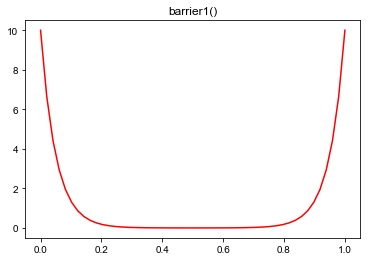

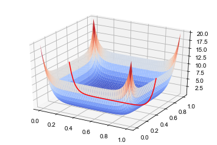

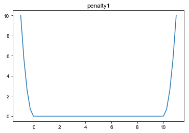

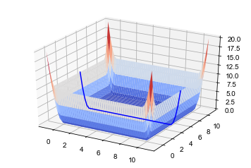

```python
# Demo barriers
xx = numpy.linspace(0,1)
yy = numpy.linspace(0,1)
X, Y = numpy.meshgrid(xx,yy)
B = numpy.zeros_like(X)
mu_B = 10
for i, (xi,yi) in enumerate(zip(X.flat,Y.flat)):
    # The domain for B is the feasible set only.
    # We want B large near boundary, but small elsewhere.
    # Feasible means c > 0 and g < 0.
    c = numpy.array([xi, yi, (1-xi), (1-yi)])
    # The length scale for the barrier
    dx = 0.05
    B.flat[i] = mu_B * barrier1(c,dx)

plt.close('all')
fig = plt.figure()
plt.plot(X[25],B[25],'r')
plt.title("barrier1()")
from mpl_toolkits.mplot3d import Axes3D
from matplotlib import cm
fig = plt.figure()
ax = fig.add_subplot(111, projection='3d')
ax.plot_surface(X,Y,B,cmap=cm.coolwarm)
ax.plot(X[25],Y[25],B[25],'r')
#pltsvg()
plt.show()

xx = numpy.linspace(-1,11)
yy = numpy.linspace(-1,11)
X, Y = numpy.meshgrid(xx,yy)
P = numpy.zeros_like(X)

mu_P = 10
for i, (xi,yi) in enumerate(zip(X.flat,Y.flat)):
    # We want P = 0 for feasible, P > 0 elsewhere
    # Feasible means c > 0 and g < 0.
    c = numpy.array([xi, yi, (10-xi), (10-yi)])
    # The length scale for the penalty
    dx = 1
    P.flat[i] = mu_P * penalty1(c, dx)

plt.close('all')
fig = plt.figure()
plt.plot(X[25],P[25])
plt.title("penalty1")
fig = plt.figure()
ax = fig.add_subplot(111, projection='3d')
ax.plot_surface(X,Y,P,cmap=cm.coolwarm)
ax.plot(X[25],Y[25],P[25],'b')
#pltsvg()
plt.show()
```

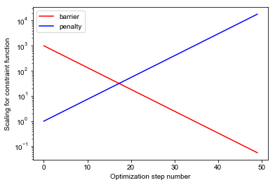

```python
step_number = numpy.arange(50)
mu_B = decay1(step_number,initial_value=1000,rate=0.2)
mu_P = grow1(step_number,initial_value=1,rate=0.2)
plt.close('all')
plt.figure()
plt.semilogy(step_number,mu_B,'r',label='barrier')
plt.semilogy(step_number,mu_P,'b',label='penalty')
plt.xlabel('Optimization step number')
plt.ylabel('Scaling for constraint function')
plt.legend()
plt.show()
```

```python
step_number = 39
mu_B = 1 * numpy.exp(0.1 * step_number)
mu_B
```

```
49.402449105530188
```

```python
class Problem_2_1:
    def __init__(self, bdry, UAgoal, mu=0.1):
        self.bdry = bdry
        self.UAgoal = UAgoal
        self.mu = mu
        self.Ncons = 7
        self.n_calls = 0
        # Soft constraints mode: this is sent to minimizer
        self.constraints = [{'type': 'ineq',
                             'fun': self.constraint,
                             'args': (i,)
                            } for i in range(self.Ncons)]

    def objective(self, xC):
        step_number = numpy.floor(self.n_calls / 7)
        self.n_calls += 1
        print(xC,flush=True)
        Q,B,P = 0.,0.,0.
        try:
            ch = system_aqua1.makeChiller(xC)
            sys = system_aqua1.System(self.bdry, ch)

            # Barriers
            # Magnitude tends to zero, slowly
            mu_B = 1000. * numpy.exp(-0.1 * step_number)
            length_scale_b = 1
            # Or ... magnitude fixed, but shape changes
            mu_B = 1000
            length_scale_b = 1 * numpy.exp(-0.1 * step_number)

            # These are zero at the boundary ...
            barriers = [ch.check_rectifier_delta_T] \
                        + [deltaT
                           for name, deltaT, epsilon, UA, Qhx in sys.data]
            B = mu_B * barrier1(barriers,length_scale_b)

            # Penalties
            # Magnitude tends to infinite
            mu_P = 1 * numpy.exp(0.1 * step_number)
            penalties = [(1.0 - sys.totalUA/self.UAgoal)]
            P = mu_P * penalty1(penalties,1)

            Q = sys.chiller.Q_evap
        except:
            Q = numpy.inf

        print(self.n_calls, step_number, Q, B, P, "\n", flush=True)
        return -Q + B + P

    def constraint(self, x, *args):
        cons = [x[0] - 0.1,
                1. - x[0],
                x[2] - x[1] - 1.0,
                x[3] - x[2] - 0.1,
                x[4] - x[1] - 10.0,
                x[5] - x[3] - 1.0,
                x[5] - x[4] - 1.0]
        if len(args) > 0:
            i, = args
            return cons[i]
        else:
            return cons

    def callback(self, x):
        print("Did an iteration at ", x)
```

```python
P = Problem_2_1(bdry, UAgoal)
```

```python
rT = T_heat_reject
x = numpy.array([0.05, 278.45, rT+7, rT+8, rT+5, 395.15])
```

```python
x = numpy.array([0.51284472, 277.97717012, 312.16427764, 313.6952877,
               310.24856734, 374.14020482])
```

```python
P.n_calls = 7 * numpy.floor(P.n_calls / 7)
opt = scipy.optimize.minimize(P.objective, x, method="COBYLA",
                              constraints=P.constraints, callback=P.callback,
                              options={'disp':True,'maxiter':1000,'rhobeg':0.05})
opt
```

```
[  3.35723183e-01   2.78159709e+02   3.12221943e+02   3.13043890e+02
   3.10475563e+02   3.95211794e+02]
```

```
Note: Absorber inlet is subcooled
267.0 38.0 118.815227129 1.83964553605e-19 5.87765955217

[  3.85723183e-01   2.78159709e+02   3.12221943e+02   3.13043890e+02
   3.10475563e+02   3.95211794e+02]
Note: Absorber inlet is subcooled
268.0 38.0 136.510643025 7.56828855898e+81 inf

[  3.35723183e-01   2.78209709e+02   3.12221943e+02   3.13043890e+02
   3.10475563e+02   3.95211794e+02]
Note: Absorber inlet is subcooled
269.0 38.0 119.02522898 2.98340116676e-18 6.27134717824

[  3.35723183e-01   2.78159709e+02   3.12271943e+02   3.13043890e+02
   3.10475563e+02   3.95211794e+02]
Note: Absorber inlet is subcooled
270.0 38.0 118.690582757 1.31818327891e-19 5.63438826919

[  3.35723183e-01   2.78159709e+02   3.12271943e+02   3.13093890e+02
   3.10475563e+02   3.95211794e+02]
Note: Absorber inlet is subcooled
271.0 38.0 118.690582757 1.31818327891e-19 5.63395309103

[  3.35723183e-01   2.78159709e+02   3.12271943e+02   3.13093890e+02
   3.10525563e+02   3.95211794e+02]
Note: Absorber inlet is subcooled
272.0 38.0 118.503217405 7.98684249975e-20 5.32600200197

[  3.35723183e-01   2.78159709e+02   3.12271943e+02   3.13093890e+02
   3.10525563e+02   3.95261794e+02]
Note: Absorber inlet is subcooled
273.0 38.0 118.586824733 9.98790131717e-20 5.48392007157

[ nan  nan  nan  nan  nan  nan]
274.0 39.0 inf 0.0 0.0

[ nan  nan  nan  nan  nan  nan]
275.0 39.0 inf 0.0 0.0

[  3.48223183e-01   2.78159709e+02   3.12271943e+02   3.13093890e+02
```

[output cut: 153 more lines]

```

[  3.35720092e-01   2.78159709e+02   3.12271948e+02   3.13093947e+02
   3.10525645e+02   3.95211783e+02]
Note: Absorber inlet is subcooled
307.0 43.0 118.501790098 3.66803421587e-34 8.77805237218

[  3.35721684e-01   2.78159757e+02   3.12271929e+02   3.13093894e+02
   3.10525561e+02   3.95211792e+02]
Note: Absorber inlet is subcooled
308.0 43.0 118.502928941 3.69946784906e-34 8.78072236229

[  3.35754329e-01   2.78159652e+02   3.12271869e+02   3.13093885e+02
   3.10525551e+02   3.95211787e+02]
Note: Absorber inlet is subcooled
309.0 44.0 118.514192111 5.71096258082e-38 9.72849873818
```

```
     fun: -108.78569337262947
   maxcv: 0.0
 message: 'Optimization terminated successfully.'
    nfev: 43
  status: 1
 success: True
       x: array([  3.35754329e-01,   2.78159652e+02,   3.12271869e+02,
         3.13093885e+02,   3.10525551e+02,   3.95211787e+02])
```

```python
x = opt.x
x
```

```
array([  3.35754329e-01,   2.78159652e+02,   3.12271869e+02,
         3.13093885e+02,   3.10525551e+02,   3.95211787e+02])
```

```python
# Let's bebug bad points encountered during optimization.
# For reference, here is a good case.
good_X1 = numpy.array([0.51284472,
                       277.97717012,
                       312.16427764,
                       313.6952877,
                       310.24856734,
                       374.14020482])
# Now, let's compare some degenerate cases.
# This one requires absorber stream to compute points at high concentrations.
bad_X1 = numpy.array([0.2,
                      290.95402556,
                      306.64229519,
                      313.6952877,
                      300.86211291,
                      384.36256216])
# This one is not feasible, insofar as it yields positive rectifier heat flow,
# that is, heat *input* to rectifier, which should be rejected as "bad" design.
# The cause is that T_abs is very low, so the rich stream is very rich,
# and in fact the rectifier isn't needed...
# So, I'm adding a constraint to keep the absorber warmer than evaporator.
bad_X2 = numpy.array([1.,
                      293.03582607,
                      308.98651075,
                      313.6952877,
                      293.29251019,
                      386.99474])
# This one is also degenerate in the rectifier.
# Try increasing the padding on the constraints.
bad_X3 = numpy.array([1.,
                      292.26696584,
                      301.95207453,
                      314.19203364,
                      293.26696584,
                      389.23622472])
bad_X4 = numpy.array([1.,
                      277.22895294,
                      278.22895294,
                      308.37781922,
                      282.22895294,
                      417.08853392])
x = good_X1
```

```python
ch = system_aqua1.makeChiller(x)
display(ch)
P.constraint(x)
```

State points

|  | T | P | x | h | s | u | v | Qu |
| --- | --- | --- | --- | --- | --- | --- | --- | --- |
| rich_abs_outlet | 310.526 | 4.90672 | 0.511574 | -71.9566 | 0.399293 | -72.5604 | 0.00123051 | 0 |
| rich_pump_outlet | 310.691 | 15.1852 | 0.511574 | -70.3759 | 0.400311 | -72.2437 | 0.00123003 | -0.001 |
| rich_shx_outlet | 350.698 | 15.1852 | 0.511574 | 112.588 | 0.954023 | 110.612 | 0.00130159 | -0.001 |
| rich_gen_sat_liquid | 352.14 | 15.1852 | 0.511574 | 119.782 | 0.974617 | 117.801 | 0.00130449 | 0 |
| weak_gen_outlet | 395.212 | 15.1852 | 0.30058 | 347.264 | 1.53717 | 345.364 | 0.00125104 | 0 |
| weak_shx_outlet | 336.73 | 15.1852 | 0.30058 | 85.2403 | 0.820382 | 83.4896 | 0.00115292 | -0.001 |
| weak_exp_outlet | 336.908 | 4.90672 | 0.30058 | 85.2402 | 0.823901 | 84.6741 | 0.00115374 | -0.001 |
| gen_vapor_outlet | 352.14 | 15.1852 | 0.988031 | 1425.08 | 4.57477 | 1269.12 | 0.102702 | 1 |
| gen_reflux_inlet | 352.14 | 15.1852 | 0.511424 | 119.346 | 0.973276 | 117.365 | 0.00130473 | 0 |
| refrig_rect_outlet | 313.094 | 15.1852 | 0.999869 | 1292.42 | 4.17683 | 1162.78 | 0.0853739 | 0.996888 |
| refrig_cond_outlet | 312.272 | 15.1852 | 0.999869 | 186.569 | 0.643511 | 183.944 | 0.00172852 | 0 |
| refrig_cehx_liquid_outlet | 295.167 | 15.1852 | 0.999869 | 103.377 | 0.369785 | 100.875 | 0.00164742 | -0.001 |
| refrig_exp_outlet | 276.772 | 4.90672 | 0.999869 | 103.377 | 0.384285 | 94.0166 | 0.0190757 | 0.0691058 |
| refrig_evap_outlet | 278.16 | 4.90672 | 0.999869 | 1273.24 | 4.59239 | 1147.59 | 0.256488 | 0.998 |
| refrig_cehx_sat_vapor | 283.618 | 4.90672 | 0.999869 | 1276.72 | 4.6039 | 1150.62 | 0.257009 | 1 |
| refrig_cehx_vapor_outlet | 310.455 | 4.90672 | 0.999869 | 1356.43 | 4.87414 | 1211.89 | 0.294582 | 1.001 |
| rectifier_liquid | 313.094 | 15.1852 | 0.97787 | 174.346 | 0.664163 | 171.765 | 0.00169968 | 0 |
| gen_vapor_formation | 395.212 | 15.1852 | 0.895272 | 1637.8 | 5.11196 | 1459.42 | 0.11747 | 1 |
| abs_vapor_final | 336.908 | 4.90672 | 0.973164 | 1448.95 | 5.15703 | 1290.6 | 0.322724 | 1 |

Performance variables

| name | unit | value |
| --- | --- | --- |
| Q_abs | kW | -181.559 |
| Q_gen | kW | 191.268 |
| Q_cond | kW | -112.029 |
| Q_evap | kW | 118.514 |
| Q_reflux | kW | -16.7246 |
| Q_shx | kW | 61.431 |
| Q_cehx | kW | 8.42784 |
| W_pump | kW | 0.53072 |
| COP | kW/kW | 0.619624 |
| ZeroCheck | kW | 3.98942e-05 |
| ZeroCheckSHX | kW | 5.60349e-06 |
| ZeroCheckCEHX | kW | -2.1214e-05 |
| Q_gen_rect_combo | kW | 174.543 |
| Q_refrig_side | kW | -6.48495 |
| ZeroCheckRect | kg/s | 0 |
| m_rich | kg/s | 0.335754 |
| m_weak | kg/s | 0.234448 |
| m_gen_vapor | kg/s | 0.103822 |
| m_gen_reflux | kg/s | 0.00251633 |
| m_refrig | kg/s | 0.101306 |
| check_rectifier_delta_T | K | 39.0464 |
| is_degenerate | bool | 0 |

```
[0.23575432887826739,
 0.66424567112173261,
 33.112217153465394,
 0.72201591814776978,
 22.365898497033925,
 81.117901789055793,
 83.686236363635032]
```

```python
sys = system_aqua1.System(bdry, ch)
sys
```

```
Note: Absorber inlet is subcooled
```

| name | deltaT | epsilon | UA | Q |
| --- | --- | --- | --- | --- |
| gen | 2.66874 | 0.944904 | 35.1378 | 191.268 |
| rect | 7.90461 | 0.811331 | 1.21624 | 16.7246 |
| abs | 1.6352 | 0.920468 | 37.6556 | 181.559 |
| cond | 2.22017 | 0.966795 | 27.4181 | 112.029 |
| evap | 1.13766 | 0.982872 | 33.1324 | 118.514 |
| total | 0 | 0 | 134.56 | 0 |

```python
1-sys.totalUA/P.UAgoal
```

```
-0.3456010499915354
```

```python
penalty1([(1 - sys.totalUA/P.UAgoal)], 1)
```

```
0.11944008575525175
```

```python
box = numpy.ones_like(x)
box[0] = 0.05
ss = numpy.linspace(-1,1,5)
yyy = numpy.zeros([len(box),len(ss)])
for i,boxi in enumerate(box):
    yy = numpy.zeros_like(ss)
    for j, s in enumerate(ss):
        x_vary = x.copy()
        x_vary[i] += boxi * s
        yyy[i,j] = P.objective(x_vary)
        if (numpy.array(P.constraint(x_vary)) < 0).any():
            yyy[i,j] = numpy.nan
```

```
[  2.85754329e-01   2.78159652e+02   3.12271869e+02   3.13093885e+02
   3.10525551e+02   3.95211787e+02]
Note: Absorber inlet is subcooled
```

```
310.0 44.0 100.865247344 1.43509581919e-55 0.0

[  3.10754329e-01   2.78159652e+02   3.12271869e+02   3.13093885e+02
   3.10525551e+02   3.95211787e+02]
Note: Absorber inlet is subcooled
311.0 44.0 109.689719727 1.55608826459e-55 0.605129864949

[  3.35754329e-01   2.78159652e+02   3.12271869e+02   3.13093885e+02
   3.10525551e+02   3.95211787e+02]
Note: Absorber inlet is subcooled
312.0 44.0 118.514192111 5.71096258082e-38 9.72849873818

[  3.60754329e-01   2.78159652e+02   3.12271869e+02   3.13093885e+02
   3.10525551e+02   3.95211787e+02]
Note: Absorber inlet is subcooled
313.0 44.0 127.338664494 4.55957213255e+27 inf

[  3.85754329e-01   2.78159652e+02   3.12271869e+02   3.13093885e+02
   3.10525551e+02   3.95211787e+02]
Note: Absorber inlet is subcooled
314.0 44.0 136.163136877 5.56939771765e+146 inf

[  3.35754329e-01   2.77159652e+02   3.12271869e+02   3.13093885e+02
   3.10525551e+02   3.95211787e+02]
Note: Absorber inlet is subcooled
315.0 44.0 114.338968687 2.40329962213e-65 2.687489943

[  3.35754329e-01   2.77659652e+02   3.12271869e+02   3.13093885e+02
   3.10525551e+02   3.95211787e+02]
Note: Absorber inlet is subcooled
316.0 45.0 116.420963016 2.15818192697e-66 5.69492376052

[  3.35754329e-01   2.78159652e+02   3.12271869e+02   3.13093885e+02
   3.10525551e+02   3.95211787e+02]
Note: Absorber inlet is subcooled
317.0 45.0 118.514192111 3.34414797942e-42 10.751653882

[  3.35754329e-01   2.78659652e+02   3.12271869e+02   3.13093885e+02
   3.10525551e+02   3.95211787e+02]
Note: Absorber inlet is subcooled
```

[output cut: 19 more lines]

```
Note: Absorber inlet is subcooled
322.0 45.0 118.514192111 3.34414797942e-42 10.751653882

[  3.35754329e-01   2.78159652e+02   3.12771869e+02   3.13093885e+02
   3.10525551e+02   3.95211787e+02]
Note: Absorber inlet is subcooled
323.0 46.0 117.262528974 4.08871513048e-50 7.81103304785

[  3.35754329e-01   2.78159652e+02   3.13271869e+02   3.13093885e+02
   3.10525551e+02   3.95211787e+02]
Note: Absorber inlet is subcooled
324.0 46.0 116.002478241 inf inf

[  3.35754329e-01   2.78159652e+02   3.12271869e+02   3.12093885e+02
   3.10525551e+02   3.95211787e+02]
```

```
Note: Absorber inlet is subcooled
325.0 46.0 118.514192111 inf inf

[  3.35754329e-01   2.78159652e+02   3.12271869e+02   3.12593885e+02
   3.10525551e+02   3.95211787e+02]
Note: Absorber inlet is subcooled
326.0 46.0 118.514192111 7.02641439392e-47 11.8866935038

[  3.35754329e-01   2.78159652e+02   3.12271869e+02   3.13093885e+02
   3.10525551e+02   3.95211787e+02]
Note: Absorber inlet is subcooled
327.0 46.0 118.514192111 7.02641439392e-47 11.8824151916

[  3.35754329e-01   2.78159652e+02   3.12271869e+02   3.13593885e+02
   3.10525551e+02   3.95211787e+02]
Note: Absorber inlet is subcooled
328.0 46.0 118.514192111 7.02641439392e-47 11.8748164182

[  3.35754329e-01   2.78159652e+02   3.12271869e+02   3.14093885e+02
   3.10525551e+02   3.95211787e+02]
Note: Absorber inlet is subcooled
329.0 46.0 118.514192111 7.02641439392e-47 11.8695190366

[  3.35754329e-01   2.78159652e+02   3.12271869e+02   3.13093885e+02
   3.09525551e+02   3.95211787e+02]
Note: Absorber inlet is subcooled
330.0 47.0 122.29076179 1.10260036825e-23 50.3356763434

[  3.35754329e-01   2.78159652e+02   3.12271869e+02   3.13093885e+02
   3.10025551e+02   3.95211787e+02]
Note: Absorber inlet is subcooled
331.0 47.0 120.394800265 1.12083178694e-46 23.7284793019

[  3.35754329e-01   2.78159652e+02   3.12271869e+02   3.13093885e+02
   3.10525551e+02   3.95211787e+02]
Note: Absorber inlet is subcooled
332.0 47.0 118.514192111 4.75597565064e-52 13.1320997062

[  3.35754329e-01   2.78159652e+02   3.12271869e+02   3.13093885e+02
   3.11025551e+02   3.95211787e+02]
```

[output cut: 17 more lines]

```

[  3.35754329e-01   2.78159652e+02   3.12271869e+02   3.13093885e+02
   3.10525551e+02   3.95211787e+02]
Note: Absorber inlet is subcooled
337.0 48.0 118.514192111 9.20587431207e-58 14.5132146886

[  3.35754329e-01   2.78159652e+02   3.12271869e+02   3.13093885e+02
   3.10525551e+02   3.95711787e+02]
Note: Absorber inlet is subcooled
338.0 48.0 119.34723381 3.92574721873e-55 19.3489855646

[  3.35754329e-01   2.78159652e+02   3.12271869e+02   3.13093885e+02
   3.10525551e+02   3.96211787e+02]
Note: Absorber inlet is subcooled
339.0 48.0 120.17342605 1.59278198962e-52 25.634194823
```

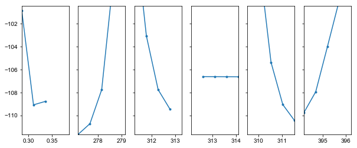

```python
plt.close('all')
plt.figure(figsize=(10, 4))
ax1=plt.subplot(1,len(box), 1)
for i,_ in enumerate(box):
    ax=plt.subplot(1, len(box), i+1, sharey=ax1)
    xxx = x[i] + ss * box[i]
    plt.plot(xxx, yyy[i,:], '.-')
    plt.setp(ax.get_yticklabels(), visible=bool(i==0))
    plt.xlim(min(xxx),max(xxx))
plt.ylim(min(yyy.flat),min(yyy.flat)*0.9)
plt.show()
```

```python
x = numpy.array([  0.31,   277.8,   313.,
         314.2,   311.5,   394.5])
```

### Trial 2.2

Just brainstorming ... As a brute-force backup, I would like to have an optimize routine that is a gradient-based method where the gradient calculation and line-search algorithms simply react to passing over the feasible boundary using exceptions instead of constraint functions. (This matters because the total UA constraint function can only be computed when the feasible heat exchange constraints are already satisfied, so in some cases it would have to return infinite values.) In other words, this would be an adaptive step size method. In pseudo-code,

```python
def optimize(fun,x0,max_iter = 100):
    x = x0.copy()
    for iter in range(max_iter):
        if step == 0:
            break
        G, H = calcGradient(fun, x)
        dx = calcLineSearch(fun, x, G, H)
        x = x + dx
        f = fun(x)
    return x, f

def calcGradient(fun, x0, max_iter = 100):
    max_iter = 100
    # Initial step sizes by component
    deltax = ones_like(x0)
    # Function values to the right
    fplus = zeros_like(x0)
    # Function values to the left
    fminus = zeros_like(x0)
    f0 = fun(x0)
    for j, _ in enumerate(deltax):
        for i in range(max_iter):
            dx = numpy.diag(deltax)[j]
            try:
                xplus = x0 + dx
                xminus = x0 - dx
                fplus[j] = fun(xplus)
                fminus[j] = fun(xminus)
                break
            except:
                deltax[j] *= 0.5
    grad, hess = calcGradHelper(f0, deltax, fplus, fminus) # TODO
    return grad, hess

def calcLineSearch(fun, x0, G, H):
    max_iter = 100
    step = 0
    direction = lshelper1(x0, G, H)
    for i in range(max_iter):
        try:
            lshelper(f
        except:
            step *= 0.5
    return step * direction
```

#### Aside

Furthermore, here is another related strategy. I could optimize first without the constraint on total UA. That would give me a feasible system. Then, given the desired total UA, I could have a feasible starting point by then turning down the mass flow rate using a linesearch on that parameter.

### Trial 2.3

Another idea (suggested in documention of early trials) is to do something different with the heat exchange feasibility constraints, utilizing energy imbalance. The final goal would be to allow UA values as inputs, and optimize the cooling capacity, as intended. An intermediate goal may be to simply demonstrate a solver with UA values as inputs (using some optimization routine to determine the temperature points that achieve the specified UA values).

### Trial 2.4

New idea: use machine learning to build constraint functions, as follows. Let the optimization routine run. For each input evaluated, classify its feasibility (bonus: add dimensions for root cause of failure). Gather the data for classified points and generate a classification function through regression, etc. Restart the optimizer with this function

### Trial 2.5

An extension of a previous idea, kind of the dual problem -- Perform optimization in two steps: first with no constraint on UA (cost) to determine maximum Q (output). Then for each Q in a set of lesser values, optimize with respect to cost. This will deliver an optimal cost vs output curve.

For the first step, since we are not interested in UA, we can be less strict with the constraints on heat exchange feasibility. Specifically, we can impose them via penalty constraints instead of barrier constraints.

```python
class Problem_2_5_A:
    def __init__(self, bdry, UAgoal, mu=0.1):
        self.bdry = bdry
        self.UAgoal = UAgoal
        self.mu = mu
        self.Ncons = 7
        self.n_calls = 0
        # Soft constraints mode: this is sent to minimizer
        self.constraints = [{'type': 'ineq',
                             'fun': self.constraint,
                             'args': (i,)
                            } for i in range(self.Ncons)]

    def objective(self, xC):
        step_number = numpy.floor(self.n_calls / 7)
        self.n_calls += 1
        print(xC,flush=True)
        Q,B,P = 0.,0.,0.
        try:
            ch = system_aqua1.makeChiller(xC)
            sys = system_aqua1.System(self.bdry, ch)

            # Barriers
            # Magnitude tends to zero, slowly
            mu_B = 1000. * numpy.exp(-0.1 * step_number)
            length_scale_b = 1
            # Or ... magnitude fixed, but shape changes
            mu_B = 1000
            length_scale_b = 1 * numpy.exp(-0.1 * step_number)

            # These are zero at the boundary ...
            barriers = [ch.check_rectifier_delta_T]
            B = mu_B * barrier1(barriers,length_scale_b)

            # Penalties
            # Magnitude tends to infinite
            mu_P = 1 * numpy.exp(0.3 * step_number)
            penalties = [deltaT - 0.01
                         for name, deltaT, epsilon, UA, Qhx in sys.data]
            P = mu_P * penalty1(penalties,1)

            Q = sys.chiller.Q_evap
        except:
            Q = numpy.inf

        print(self.n_calls, step_number, Q, B, P, "\n", flush=True)
        return -Q + B + P

    def constraint(self, x, *args):
        cons = [x[0] - 0.1,
                1. - x[0],
                x[2] - x[1] - 1.0,
                x[3] - x[2] - 0.1,
                x[4] - x[1] - 10.0,
                x[5] - x[3] - 1.0,
                x[5] - x[4] - 1.0]
        if len(args) > 0:
            i, = args
            return cons[i]
        else:
            return cons

    def callback(self, x):
        print("Did an iteration at ", x)
```

```python
P = Problem_2_5_A(bdry, UAgoal)
rT = T_heat_reject
x = numpy.array([0.05, 278.45, rT+7, rT+8, rT+5, 395.15])
```

```python
P.n_calls = 7 * numpy.floor(P.n_calls / 7)
opt = scipy.optimize.minimize(P.objective, x, method="COBYLA",
                              constraints=P.constraints, callback=P.callback,
                              options={'disp':True,'maxiter':1000,'rhobeg':0.001})
opt
```

```
[  3.54011747e-01   2.78602326e+02   3.11987016e+02   3.13008619e+02
   3.09938338e+02   3.95252752e+02]
```

```
Note: Absorber inlet is subcooled
```

```
183.0 26.0 130.079516499 3.2465978731e-217 0.0576251119286

[  3.55011747e-01   2.78602326e+02   3.11987016e+02   3.13008619e+02
   3.09938338e+02   3.95252752e+02]
Note: Absorber inlet is subcooled
184.0 26.0 130.446960567 3.2465978731e-217 1.75826559506

[  3.54011747e-01   2.78603326e+02   3.11987016e+02   3.13008619e+02
   3.09938338e+02   3.95252752e+02]
Note: Absorber inlet is subcooled
185.0 26.0 130.08398977 3.30312287019e-217 0.0914806458042

[  3.54011747e-01   2.78602326e+02   3.11988016e+02   3.13008619e+02
   3.09938338e+02   3.95252752e+02]
Note: Absorber inlet is subcooled
186.0 26.0 130.076923393 3.19477325953e-217 0.0540044838839

[  3.54011747e-01   2.78602326e+02   3.11988016e+02   3.13009619e+02
   3.09938338e+02   3.95252752e+02]
Note: Absorber inlet is subcooled
187.0 26.0 130.076923393 3.23807771555e-217 0.0540044838839

[  3.54011747e-01   2.78602326e+02   3.11988016e+02   3.13008619e+02
   3.09939338e+02   3.95252752e+02]
Note: Absorber inlet is subcooled
188.0 26.0 130.072917502 3.14686552989e-217 0.0486421447564

[  3.54011747e-01   2.78602326e+02   3.11988016e+02   3.13008619e+02
   3.09939338e+02   3.95253752e+02]
Note: Absorber inlet is subcooled
189.0 26.0 130.074644751 3.14686552989e-217 0.0509198869268

[  3.53011991e-01   2.78602304e+02   3.11988017e+02   3.13008619e+02
   3.09939339e+02   3.95252752e+02]
Note: Absorber inlet is subcooled
190.0 27.0 129.705476555 2.58489344581e-240 0.0

[  3.54509639e-01   2.78602281e+02   3.11988018e+02   3.13008619e+02
   3.09939340e+02   3.95252752e+02]
Note: Absorber inlet is subcooled
```

[output cut: 71 more lines]

```

[  3.54011632e-01   2.78602326e+02   3.11988052e+02   3.13008584e+02
   3.09939338e+02   3.95252752e+02]
Note: Absorber inlet is subcooled
206.0 29.0 130.07278167 5.04096989069e-294 0.119205800851

[  3.54026579e-01   2.78602304e+02   3.11988066e+02   3.13008701e+02
   3.09939340e+02   3.95252757e+02]
Note: Absorber inlet is subcooled
207.0 29.0 130.07814301 5.04750184842e-294 0.135729043157

[  3.54051235e-01   2.78602285e+02   3.11987952e+02   3.13008610e+02
   3.09939387e+02   3.95252762e+02]
Note: Absorber inlet is subcooled
208.0 29.0 130.087226628 5.04438564639e-294 0.167294168501
```

```
     fun: -129.91993245970548
   maxcv: 0.0
 message: 'Optimization terminated successfully.'
    nfev: 26
  status: 1
 success: True
       x: array([  3.54051235e-01,   2.78602285e+02,   3.11987952e+02,
         3.13008610e+02,   3.09939387e+02,   3.95252762e+02])
```

```python
x = opt.x
x
```

```
array([  3.54051235e-01,   2.78602285e+02,   3.11987952e+02,
         3.13008610e+02,   3.09939387e+02,   3.95252762e+02])
```

```python
ch = system_aqua1.makeChiller(x)
display(ch)
```

State points

|  | T | P | x | h | s | u | v | Qu |
| --- | --- | --- | --- | --- | --- | --- | --- | --- |
| rich_abs_outlet | 309.939 | 4.98571 | 0.518919 | -74.179 | 0.390575 | -74.7943 | 0.0012341 | 0 |
| rich_pump_outlet | 310.102 | 15.0651 | 0.518919 | -72.6244 | 0.391578 | -74.4829 | 0.00123364 | -0.001 |
| rich_shx_outlet | 349.632 | 15.0651 | 0.518919 | 108.341 | 0.940607 | 106.375 | 0.00130486 | -0.001 |
| rich_gen_sat_liquid | 350.548 | 15.0651 | 0.518919 | 112.646 | 0.952907 | 110.677 | 0.00130693 | 0 |
| weak_gen_outlet | 395.253 | 15.0651 | 0.298796 | 348.035 | 1.53813 | 346.152 | 0.00124995 | 0 |
| weak_shx_outlet | 336.331 | 15.0651 | 0.298796 | 84.2451 | 0.816148 | 82.5102 | 0.00115162 | -0.001 |
| weak_exp_outlet | 336.506 | 4.98571 | 0.298796 | 84.2451 | 0.819599 | 83.6705 | 0.00115242 | -0.001 |
| gen_vapor_outlet | 350.548 | 15.0651 | 0.989069 | 1420.13 | 4.56407 | 1265 | 0.102976 | 1 |
| gen_reflux_inlet | 350.548 | 15.0651 | 0.518918 | 112.644 | 0.952898 | 110.675 | 0.00130694 | 0 |
| refrig_rect_outlet | 313.009 | 15.0651 | 0.999869 | 1294.32 | 4.18595 | 1164.39 | 0.0862463 | 0.998019 |
| refrig_cond_outlet | 311.988 | 15.0651 | 0.999869 | 185.16 | 0.639058 | 182.558 | 0.0017271 | 0 |
| refrig_cehx_liquid_outlet | 295.201 | 15.0651 | 0.999869 | 103.531 | 0.370375 | 101.049 | 0.00164758 | -0.001 |
| refrig_exp_outlet | 277.213 | 4.98571 | 0.999869 | 103.531 | 0.384338 | 94.3282 | 0.0184585 | 0.0676894 |
| refrig_evap_outlet | 278.602 | 4.98571 | 0.999869 | 1273.75 | 4.58754 | 1147.98 | 0.252921 | 0.998 |
| refrig_cehx_sat_vapor | 284.063 | 4.98571 | 0.999869 | 1290.14 | 4.64428 | 1160.96 | 0.259104 | 1 |
| refrig_cehx_vapor_outlet | 310.209 | 4.98571 | 0.999869 | 1355.38 | 4.86333 | 1211.09 | 0.289409 | 1.001 |
| rectifier_liquid | 313.009 | 15.0651 | 0.972268 | 169.756 | 0.662027 | 167.209 | 0.00169108 | 0 |
| gen_vapor_formation | 395.253 | 15.0651 | 0.894028 | 1639.65 | 5.11954 | 1461.18 | 0.118466 | 1 |
| abs_vapor_final | 336.506 | 4.98571 | 0.974441 | 1446.2 | 5.1419 | 1288.13 | 0.317044 | 1 |

Performance variables

| name | unit | value |
| --- | --- | --- |
| Q_abs | kW | -197.396 |
| Q_gen | kW | 207.383 |
| Q_cond | kW | -123.3 |
| Q_evap | kW | 130.087 |
| Q_reflux | kW | -17.3245 |
| Q_shx | kW | 64.0709 |
| Q_cehx | kW | 9.07422 |
| W_pump | kW | 0.550401 |
| COP | kW/kW | 0.627282 |
| ZeroCheck | kW | 2.52954e-05 |
| ZeroCheckSHX | kW | 5.78258e-06 |
| ZeroCheckCEHX | kW | -1.87975e-05 |
| Q_gen_rect_combo | kW | 190.058 |
| Q_refrig_side | kW | -6.78717 |
| ZeroCheckRect | kg/s | 1.38778e-17 |
| m_rich | kg/s | 0.354051 |
| m_weak | kg/s | 0.242886 |
| m_gen_vapor | kg/s | 0.113719 |
| m_gen_reflux | kg/s | 0.00255368 |
| m_refrig | kg/s | 0.111165 |
| check_rectifier_delta_T | K | 37.5396 |
| is_degenerate | bool | 0 |

```python
P.constraint(x)
```

```
[0.25405123492903559,
 0.64594876507096444,
 32.385666581057876,
 0.92065803869669482,
 21.337102338183058,
 81.244151889835393,
 84.313374171406906]
```

```python
sys = system_aqua1.System(bdry, ch)
sys
```

```
Note: Absorber inlet is subcooled
```

| name | deltaT | epsilon | UA | Q |
| --- | --- | --- | --- | --- |
| gen | 0.163144 | 0.996723 | 78.2634 | 207.383 |
| rect | 7.88064 | 0.782762 | 1.34955 | 17.3245 |
| abs | 0.795894 | 0.959961 | 63.3603 | 197.396 |
| cond | 1.42142 | 0.967853 | 37.4399 | 123.3 |
| evap | 0.00472091 | 0.999394 | 123.917 | 130.087 |
| total | 0 | 0 | 304.33 | 0 |

```python
box = numpy.ones_like(x)
box[0] = 0.05
ss = numpy.linspace(-1,1,5)
yyy = numpy.zeros([len(box),len(ss)])
for i,boxi in enumerate(box):
    yy = numpy.zeros_like(ss)
    for j, s in enumerate(ss):
        x_vary = x.copy()
        x_vary[i] += boxi * s
        yyy[i,j] = P.objective(x_vary)
        if (numpy.array(P.constraint(x_vary)) < 0).any():
            yyy[i,j] = numpy.nan
```

```
[  3.04051235e-01   2.78602285e+02   3.11987952e+02   3.13008610e+02
   3.09939387e+02   3.95252762e+02]
Note: Absorber inlet is subcooled
```

```
209.0 29.0 111.715983459 5.04438564639e-294 0.0

[  3.29051235e-01   2.78602285e+02   3.11987952e+02   3.13008610e+02
   3.09939387e+02   3.95252762e+02]
Note: Absorber inlet is subcooled
210.0 29.0 120.901605043 5.04438564639e-294 0.0

[  3.54051235e-01   2.78602285e+02   3.11987952e+02   3.13008610e+02
   3.09939387e+02   3.95252762e+02]
Note: Absorber inlet is subcooled
211.0 30.0 130.087226628 0.0 0.225823506808

[  3.79051235e-01   2.78602285e+02   3.11987952e+02   3.13008610e+02
   3.09939387e+02   3.95252762e+02]
Note: Absorber inlet is subcooled
212.0 30.0 139.272848213 0.0 91312.5800127

[   0.40405123  278.60228502  311.98795161  313.00860964  309.93938736
  395.25276153]
Note: Absorber inlet is subcooled
213.0 30.0 148.458469798 0.0 382344.140072

[  3.54051235e-01   2.77602285e+02   3.11987952e+02   3.13008610e+02
   3.09939387e+02   3.95252762e+02]
Note: Absorber inlet is subcooled
214.0 30.0 125.639385167 0.0 0.0

[  3.54051235e-01   2.78102285e+02   3.11987952e+02   3.13008610e+02
   3.09939387e+02   3.95252762e+02]
Note: Absorber inlet is subcooled
215.0 30.0 127.856921936 0.0 0.0

[  3.54051235e-01   2.78602285e+02   3.11987952e+02   3.13008610e+02
   3.09939387e+02   3.95252762e+02]
Note: Absorber inlet is subcooled
216.0 30.0 130.087226628 0.0 0.225823506808

[  3.54051235e-01   2.79102285e+02   3.11987952e+02   3.13008610e+02
   3.09939387e+02   3.95252762e+02]
Note: Absorber inlet is subcooled
217.0 30.0 132.330795742 1.33397724377e-319 3292.04125993

[  3.54051235e-01   2.79602285e+02   3.11987952e+02   3.13008610e+02
   3.09939387e+02   3.95252762e+02]
Note: Absorber inlet is subcooled
218.0 31.0 134.588138876 0.0 17656.5666321

[  3.54051235e-01   2.78602285e+02   3.10987952e+02   3.13008610e+02
   3.09939387e+02   3.95252762e+02]
Note: Absorber inlet is subcooled
219.0 31.0 132.663846055 0.0 277.986858117

[  3.54051235e-01   2.78602285e+02   3.11487952e+02   3.13008610e+02
   3.09939387e+02   3.95252762e+02]
Note: Absorber inlet is subcooled
```

```
220.0 31.0 131.379717522 0.0 74.6268927787

[  3.54051235e-01   2.78602285e+02   3.11987952e+02   3.13008610e+02
   3.09939387e+02   3.95252762e+02]
Note: Absorber inlet is subcooled
221.0 31.0 130.087226628 0.0 0.304829849622

[  3.54051235e-01   2.78602285e+02   3.12487952e+02   3.13008610e+02
   3.09939387e+02   3.95252762e+02]
Note: Absorber inlet is subcooled
222.0 31.0 128.78623555 0.0 0.0

[  3.54051235e-01   2.78602285e+02   3.12987952e+02   3.13008610e+02
   3.09939387e+02   3.95252762e+02]
Note: Absorber inlet is subcooled
223.0 31.0 127.476602663 0.0 9454794.92894

[  3.54051235e-01   2.78602285e+02   3.11987952e+02   3.12008610e+02
   3.09939387e+02   3.95252762e+02]
Note: Absorber inlet is subcooled
224.0 31.0 130.087226628 0.0 10517865.4852

[  3.54051235e-01   2.78602285e+02   3.11987952e+02   3.12508610e+02
   3.09939387e+02   3.95252762e+02]
Note: Absorber inlet is subcooled
225.0 32.0 130.087226628 0.0 0.411477257324

[  3.54051235e-01   2.78602285e+02   3.11987952e+02   3.13008610e+02
   3.09939387e+02   3.95252762e+02]
Note: Absorber inlet is subcooled
226.0 32.0 130.087226628 0.0 0.411477257324

[  3.54051235e-01   2.78602285e+02   3.11987952e+02   3.13508610e+02
   3.09939387e+02   3.95252762e+02]
Note: Absorber inlet is subcooled
227.0 32.0 130.087226628 0.0 0.411477257324

[  3.54051235e-01   2.78602285e+02   3.11987952e+02   3.14008610e+02
   3.09939387e+02   3.95252762e+02]
Note: Absorber inlet is subcooled
```

[output cut: 36 more lines]

```

[  3.54051235e-01   2.78602285e+02   3.11987952e+02   3.13008610e+02
   3.09939387e+02   3.95252762e+02]
Note: Absorber inlet is subcooled
236.0 33.0 130.087226628 0.0 0.555436199917

[  3.54051235e-01   2.78602285e+02   3.11987952e+02   3.13008610e+02
   3.09939387e+02   3.95752762e+02]
Note: Absorber inlet is subcooled
237.0 33.0 130.947401112 0.0 1003.50823437

[  3.54051235e-01   2.78602285e+02   3.11987952e+02   3.13008610e+02
   3.09939387e+02   3.96252762e+02]
Note: Absorber inlet is subcooled
238.0 33.0 131.800531689 0.0 7052.36078554
```

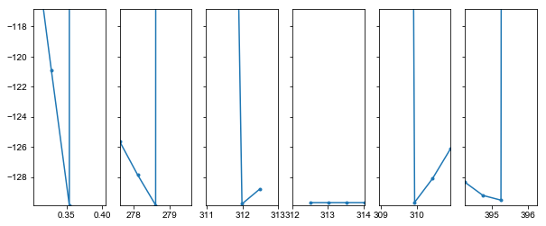

```python
plt.close('all')
plt.figure(figsize=(10, 4))
ax1=plt.subplot(1,len(box), 1)
for i,_ in enumerate(box):
    ax=plt.subplot(1, len(box), i+1, sharey=ax1)
    xxx = x[i] + ss * box[i]
    plt.plot(xxx, yyy[i,:], '.-')
    plt.setp(ax.get_yticklabels(), visible=bool(i==0))
    plt.xlim(min(xxx),max(xxx))
plt.ylim(min(yyy.flat),min(yyy.flat)*0.9)
plt.show()
```

Now that we have a guess for the maximum cooling we might get, let's optimize the cost function instead, and ask for that much cooling using a constraint. I'm thinking that a penalty constraint might be good, so that we add this to the objective:

$$ P = \left(Q - Q_{goal}\right) ^ 2 $$

```python
Q_opt = ch.Q_evap
Q_opt
```

```
130.08722662820685
```

```python
Q_goal = 0.9 * Q_opt
Q_goal
```

```
117.07850396538616
```

```python
class Problem_2_5_B:
    def __init__(self, bdry, Q_goal, mu=0.1):
        self.bdry = bdry
        self.Q_goal = Q_goal
        self.mu = mu
        self.Ncons = 7
        self.n_calls = 0
        # Soft constraints mode: this is sent to minimizer
        self.constraints = [{'type': 'ineq',
                             'fun': self.constraint,
                             'args': (i,)
                            } for i in range(self.Ncons)]

    def objective_raw(self, xC):
        try:
            ch = system_aqua1.makeChiller(xC)
            sys = system_aqua1.System(self.bdry, ch)
            UA = sys.totalUA
        except:
            UA = numpy.nan
        return UA


    def objective(self, xC):
        step_number = numpy.floor(self.n_calls / 7)
        self.n_calls += 1
        print(xC,flush=True)
        UA,B,P = 0.,0.,0.
        try:
            ch = system_aqua1.makeChiller(xC)
            sys = system_aqua1.System(self.bdry, ch)

            # Barriers
            # Magnitude tends to zero, slowly
            mu_B = 1000. * numpy.exp(-0.1 * step_number)
            length_scale_b = 1
            # Or ... magnitude fixed, but shape changes
            mu_B = 1000
            length_scale_b = 1 * numpy.exp(-0.1 * step_number)

            # These are zero at the boundary ...
            barriers = [ch.check_rectifier_delta_T] \
                       + [deltaT
                          for name, deltaT, epsilon, UA, Qhx in sys.data]
            B = mu_B * barrier1(barriers,length_scale_b)

            # Penalties
            # Magnitude tends to infinite
            mu_P = 1 * numpy.exp(0.3 * step_number)
            penalties = [ch.Q_evap - self.Q_goal]
            P = mu_P * penalty1(penalties,1)

            UA = sys.totalUA
        except:
            UA = numpy.inf

        print(self.n_calls, step_number, UA, B, P, "\n", flush=True)
        return UA + B + P

    def constraint(self, x, *args):
        cons = [x[0] - 0.1,
                1. - x[0],
                x[2] - x[1] - 1.0,
                x[3] - x[2] - 0.1,
                x[4] - x[1] - 10.0,
                x[5] - x[3] - 1.0,
                x[5] - x[4] - 1.0]
        if len(args) > 0:
            i, = args
            return cons[i]
        else:
            return cons

    def callback(self, x):
        print("Did an iteration at ", x)
```

```python
P = Problem_2_5_B(bdry, Q_goal)
rT = T_heat_reject
x2 = x.copy()
```

```python
P.n_calls = 7 * numpy.floor(P.n_calls / 7)
opt = scipy.optimize.minimize(P.objective, x2, method="COBYLA",
                              constraints=P.constraints, callback=P.callback,
                              options={'disp':True,'maxiter':100,'rhobeg':0.01})
opt
```

```
[  3.23139528e-01   2.78641275e+02   3.12291755e+02   3.13259021e+02
   3.10228713e+02   3.95250062e+02]
```

```
Note: Absorber inlet is subcooled
```

```
176.0 25.0 138.19835208991435 0.118474468961 0.0

[  3.33139528e-01   2.78641275e+02   3.12291755e+02   3.13259021e+02
   3.10228713e+02   3.95250062e+02]
Note: Absorber inlet is subcooled
177.0 25.0 153.19282242496664 1.65573909183 0.0

[  3.23139528e-01   2.78651275e+02   3.12291755e+02   3.13259021e+02
   3.10228713e+02   3.95250062e+02]
Note: Absorber inlet is subcooled
178.0 25.0 138.537420450732 0.137721707638 0.0

[  3.23139528e-01   2.78641275e+02   3.12301755e+02   3.13259021e+02
   3.10228713e+02   3.95250062e+02]
Note: Absorber inlet is subcooled
179.0 25.0 138.02564423858303 0.11642563615 0.0

[  3.23139528e-01   2.78641275e+02   3.12301755e+02   3.13269021e+02
   3.10228713e+02   3.95250062e+02]
Note: Absorber inlet is subcooled
180.0 25.0 138.02541019578706 0.11642563615 0.0

[  3.23139528e-01   2.78641275e+02   3.12301755e+02   3.13269021e+02
   3.10238713e+02   3.95250062e+02]
Note: Absorber inlet is subcooled
181.0 25.0 137.76089753239407 0.113325785726 1.90304608771

[  3.23139528e-01   2.78641275e+02   3.12301755e+02   3.13269021e+02
   3.10228713e+02   3.95260062e+02]
Note: Absorber inlet is subcooled
182.0 25.0 138.11933928130702 0.117784938847 0.0

[  3.13191132e-01   2.78641059e+02   3.12301860e+02   3.13269021e+02
   3.10227729e+02   3.95250004e+02]
Note: Absorber inlet is subcooled
183.0 26.0 126.25881782715973 0.00255257049659 31599.5423089

[  3.28139528e-01   2.78641275e+02   3.12301755e+02   3.13269021e+02
   3.10228713e+02   3.95250062e+02]
Note: Absorber inlet is subcooled
```

[output cut: 201 more lines]

```

[  3.23299823e-01   2.78637997e+02   3.12304870e+02   3.13272146e+02
   3.10228919e+02   3.95249905e+02]
Note: Absorber inlet is subcooled
225.0 32.0 138.0648863875587 1.1555744577e-05 0.0

[  3.23196277e-01   2.78637994e+02   3.12304828e+02   3.13272146e+02
   3.10228921e+02   3.95249905e+02]
Note: Absorber inlet is subcooled
226.0 32.0 137.92979221852897 1.09372746236e-05 0.0

[  3.23096349e-01   2.78637991e+02   3.12304830e+02   3.13272146e+02
   3.10228923e+02   3.95249904e+02]
Note: Absorber inlet is subcooled
227.0 32.0 137.7989944411681 1.03703770245e-05 16.4138635888
```

```
     fun: 154.21286840036998
   maxcv: 0.0
 message: 'Optimization terminated successfully.'
    nfev: 52
  status: 1
 success: True
       x: array([  3.23096349e-01,   2.78637991e+02,   3.12304830e+02,
         3.13272146e+02,   3.10228923e+02,   3.95249904e+02])
```

```python
x2 = opt.x
x2
```

```
array([  3.23096349e-01,   2.78637991e+02,   3.12304830e+02,
         3.13272146e+02,   3.10228923e+02,   3.95249904e+02])
```

```python
ch2 = system_aqua1.makeChiller(x2)
display(ch2)
```

State points

|  | T | P | x | h | s | u | v | Qu |
| --- | --- | --- | --- | --- | --- | --- | --- | --- |
| rich_abs_outlet | 310.229 | 4.99213 | 0.517237 | -72.9791 | 0.394813 | -73.5949 | 0.00123348 | 0 |
| rich_pump_outlet | 310.394 | 15.1992 | 0.517237 | -71.4056 | 0.395827 | -73.2797 | 0.00123301 | -0.001 |
| rich_shx_outlet | 350.055 | 15.1992 | 0.517237 | 110.147 | 0.946042 | 108.164 | 0.00130451 | -0.001 |
| rich_gen_sat_liquid | 351.206 | 15.1992 | 0.517237 | 115.56 | 0.961482 | 113.573 | 0.00130711 | 0 |
| weak_gen_outlet | 395.25 | 15.1992 | 0.300604 | 347.435 | 1.53761 | 345.533 | 0.00125114 | 0 |
| weak_shx_outlet | 336.536 | 15.1992 | 0.300604 | 84.3913 | 0.817873 | 82.6393 | 0.0011527 | -0.001 |
| weak_exp_outlet | 336.713 | 4.99213 | 0.300604 | 84.3913 | 0.821369 | 83.8154 | 0.00115351 | -0.001 |
| gen_vapor_outlet | 351.206 | 15.1992 | 0.988756 | 1421.67 | 4.56463 | 1266.29 | 0.102232 | 1 |
| gen_reflux_inlet | 351.206 | 15.1992 | 0.517235 | 115.557 | 0.961473 | 113.57 | 0.00130711 | 0 |
| refrig_rect_outlet | 313.272 | 15.1992 | 0.999869 | 1293.92 | 4.18118 | 1164.05 | 0.0854417 | 0.997783 |
| refrig_cond_outlet | 312.305 | 15.1992 | 0.999869 | 186.732 | 0.644028 | 184.105 | 0.00172869 | 0 |
| refrig_cehx_liquid_outlet | 295.393 | 15.1992 | 0.999869 | 104.452 | 0.373417 | 101.946 | 0.00164842 | -0.001 |
| refrig_exp_outlet | 277.249 | 4.99213 | 0.999869 | 104.452 | 0.387603 | 95.1713 | 0.0185898 | 0.0682992 |
| refrig_evap_outlet | 278.638 | 4.99213 | 0.999869 | 1273.79 | 4.58715 | 1148.02 | 0.252636 | 0.998 |
| refrig_cehx_sat_vapor | 284.09 | 4.99213 | 0.999869 | 1290.15 | 4.64374 | 1160.97 | 0.258776 | 1 |
| refrig_cehx_vapor_outlet | 310.512 | 4.99213 | 0.999869 | 1356.07 | 4.86496 | 1211.62 | 0.289356 | 1.001 |
| rectifier_liquid | 313.272 | 15.1992 | 0.973847 | 172.236 | 0.666416 | 169.66 | 0.00169463 | 0 |
| gen_vapor_formation | 395.25 | 15.1992 | 0.895238 | 1637.88 | 5.11174 | 1459.49 | 0.117368 | 1 |
| abs_vapor_final | 336.713 | 4.99213 | 0.974155 | 1446.98 | 5.14349 | 1288.81 | 0.316831 | 1 |

Performance variables

| name | unit | value |
| --- | --- | --- |
| Q_abs | kW | -178.135 |
| Q_gen | kW | 187.274 |
| Q_cond | kW | -110.824 |
| Q_evap | kW | 117.045 |
| Q_reflux | kW | -15.8689 |
| Q_shx | kW | 58.659 |
| Q_cehx | kW | 8.23591 |
| W_pump | kW | 0.508389 |
| COP | kW/kW | 0.624994 |
| ZeroCheck | kW | 2.9251e-05 |
| ZeroCheckSHX | kW | 5.39052e-06 |
| ZeroCheckCEHX | kW | -1.90222e-05 |
| Q_gen_rect_combo | kW | 171.405 |
| Q_refrig_side | kW | -6.22118 |
| ZeroCheckRect | kg/s | 1.38778e-17 |
| m_rich | kg/s | 0.323096 |
| m_weak | kg/s | 0.223001 |
| m_gen_vapor | kg/s | 0.102454 |
| m_gen_reflux | kg/s | 0.00235899 |
| m_refrig | kg/s | 0.100095 |
| check_rectifier_delta_T | K | 37.9343 |
| is_degenerate | bool | 0 |

```python
P.constraint(x2)
```

```
[0.22309634851689678,
 0.67690365148310327,
 32.666838464731313,
 0.86731647569055215,
 21.590932006864364,
 80.97775799049748,
 84.020980924054982]
```

```python
sys2 = system_aqua1.System(bdry, ch2)
sys2
```

```
Note: Absorber inlet is subcooled
```

| name | deltaT | epsilon | UA | Q |
| --- | --- | --- | --- | --- |
| gen | 4.75025 | 0.92018 | 28.5516 | 187.274 |
| rect | 8.15244 | 0.782637 | 1.12489 | 15.8689 |
| abs | 1.1977 | 0.940514 | 42.4473 | 178.135 |
| cond | 2.31615 | 0.96672 | 26.5502 | 110.824 |
| evap | 0.749386 | 0.983799 | 39.125 | 117.045 |
| total | 0 | 0 | 137.799 | 0 |

```python
box = numpy.ones_like(x2)
box[0] = 0.05
ss = numpy.linspace(-1,1,5)
yyy = numpy.zeros([len(box),len(ss)])
for i,boxi in enumerate(box):
    yy = numpy.zeros_like(ss)
    for j, s in enumerate(ss):
        x_vary = x2.copy()
        x_vary[i] += boxi * s
        yyy[i,j] = P.objective_raw(x_vary)
        if (numpy.array(P.constraint(x_vary)) < 0).any():
            yyy[i,j] = numpy.nan
```

```
Note: Absorber inlet is subcooled
```

```
Note: Absorber inlet is subcooled
Note: Absorber inlet is subcooled
Note: Absorber inlet is subcooled
```

```
Note: Absorber inlet is subcooled
Note: Absorber inlet is subcooled
Note: Absorber inlet is subcooled
Note: Absorber inlet is subcooled
Note: Absorber inlet is subcooled
Note: Absorber inlet is subcooled
Note: Absorber inlet is subcooled
Note: Absorber inlet is subcooled
Note: Absorber inlet is subcooled
Note: Absorber inlet is subcooled
Note: Absorber inlet is subcooled
Note: Absorber inlet is subcooled
Note: Absorber inlet is subcooled
Note: Absorber inlet is subcooled
Note: Absorber inlet is subcooled
Note: Absorber inlet is subcooled
Note: Absorber inlet is subcooled
Note: Absorber inlet is subcooled
Note: Absorber inlet is subcooled
Note: Absorber inlet is subcooled
```

```
Note: Absorber inlet is subcooled
Note: Absorber inlet is subcooled
Note: Absorber inlet is subcooled
Note: Absorber inlet is subcooled
Note: Absorber inlet is subcooled
Note: Absorber inlet is subcooled
```

```python
yyy
```

```
array([[  92.85015493,  111.63476306,  137.79899444,  191.02442712,
                  inf],
       [ 116.37203437,  125.02773452,  137.79899444,  170.21816617,
                  inf],
       [ 160.89854932,  147.57478175,  137.79899444,  130.09642707,
                  nan],
       [          nan,  137.81416839,  137.79899444,  137.78949491,
         137.78336925],
       [ 209.06261669,  155.59632572,  137.79899444,  126.91870377,
         119.04386542],
       [ 129.11684491,  133.29755777,  137.79899444,  142.67851534,
         148.01130393]])
```

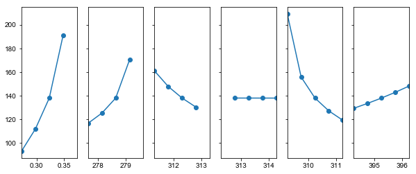

```python
plt.close('all')
plt.figure(figsize=(10, 4))
ax1=plt.subplot(1,len(box), 1)
for i,_ in enumerate(box):
    ax=plt.subplot(1, len(box), i+1, sharey=ax1)
    xxx = x2[i] + ss * box[i]
    plt.plot(xxx, yyy[i,:], 'o-')
    plt.setp(ax.get_yticklabels(), visible=bool(i==0))
    plt.xlim(min(xxx),max(xxx))
#plt.ylim(min(yyy.flat)*0.9,min(yyy.flat))
plt.show()
```

The sensitivity plot could go further by overlaying the constraint functions. Additionally, it would be nice to find the eigenvectors of the objective function and trace in those directions, indicating how far it is to the next constraint. But that is icing on the cake, so meanwhile I will continue with this approach in a new notebook and generate some parametric study data.

# Scratch work

```python
a=5
for i in range(9999):
    a*=0.5
    if a==0:
        break
i,a
```

```
(1076, 0.0)
```

```python
gradient_step = numpy.array([1.,2.,3.,4.])
for j, _ in enumerate(gradient_step):
    for i in range(2):
        gradient_step[j] *= 0.5
gradient_step
```

```
array([ 0.25,  0.5 ,  0.75,  1.  ])
```

```python
numpy.diag(gradient_step)[3]
```

```
array([ 0.,  0.,  0.,  1.])
```

```python
%%html
<pre id="TOC-markdown">TOC will be here</pre>
<script>
$("#TOC-markdown").html(
    $('h1,h2,h3,h4').filter(":has(a)").map(function(){return "  ".repeat($(this).prop("tagName")[1]) + "- ["+$(this).text()+"](" + $(this).children().attr("href") + ")";}).get().join("\n")
    );
</script>
```

[output not shown]